# The Space Race and Beyond: A Statistical History of Global Space Launches

# 3 The Cold War Space Race in Detail

## 3.1 Who Was Launching — and How Many?

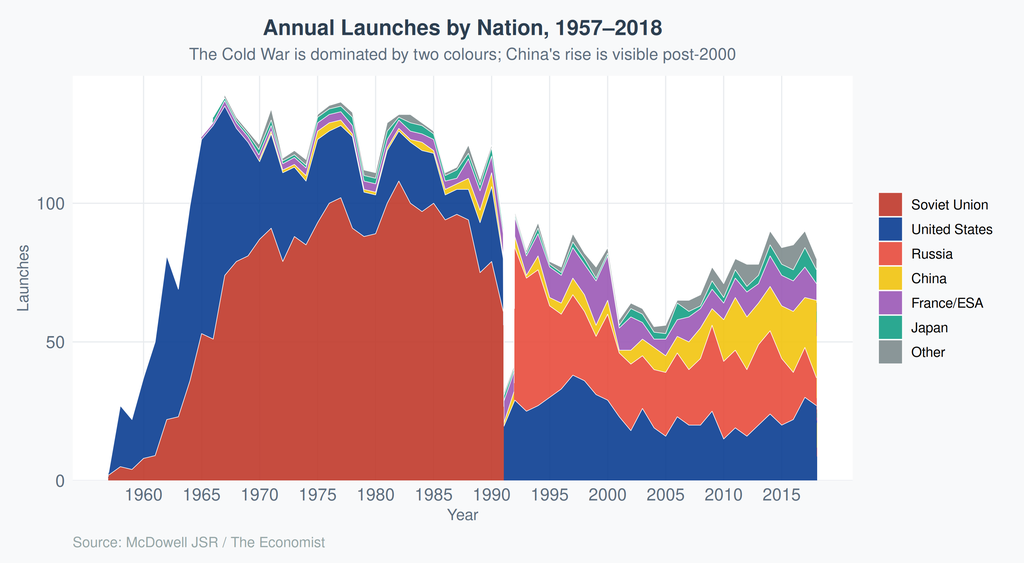

Stacked area chart of annual launches by the six most active spacefaring nations. Here USSR and Russia depicted as different states.

## 3.2 Total Launches by Nation — All-Time

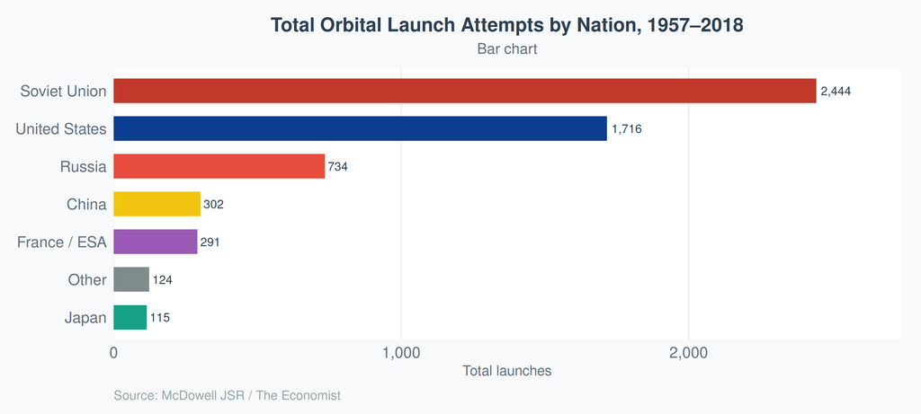

Total launches by nation across the full 1957–2018 period.

The Soviet Union’s 2,444 launches account for **42.7%** of all attempts in the dataset. The United States follows with 1,716 launches which corresponds to **30%** out of total 5726 launches. Together, the two Cold War rivals are responsible for 72.7% of humanity’s orbital launch history.

# 4 Reliability: The Quest for Success

## 4.1 Failure Rates by Decade

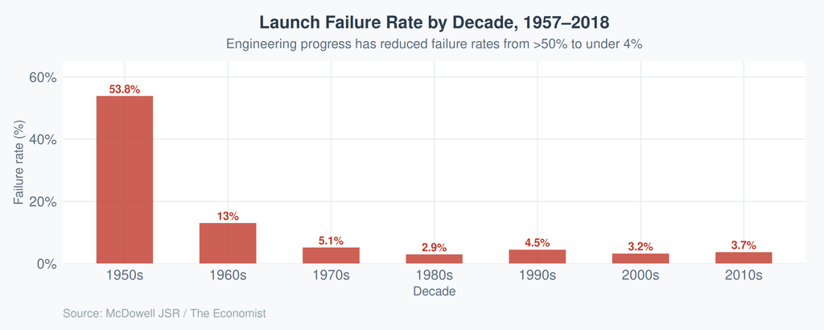

Launch failure rate (%) by decade. The early years of rocketry were extraordinarily hazardous; modern reliability exceeds 96%.

The improvement in reliability is one of the great engineering success stories of the 20th century. In the **1950s**, over half of all launches failed — rockets were experimental machines pushed far beyond tested limits and were deployed without too much testing. The feeling for competition was stronger than willingness to make reliable machines. By the **1980s**, failure rates had fallen below 3%, and the 2000s achieved roughly one failure in 30 attempts.

## 4.2 Annual Success Rate Trend

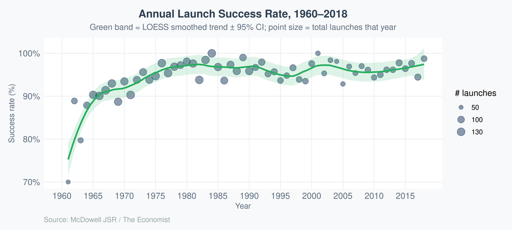

# 5 The Rise of Private Space

## 5.1 State vs. Commercial vs. Startup Launches

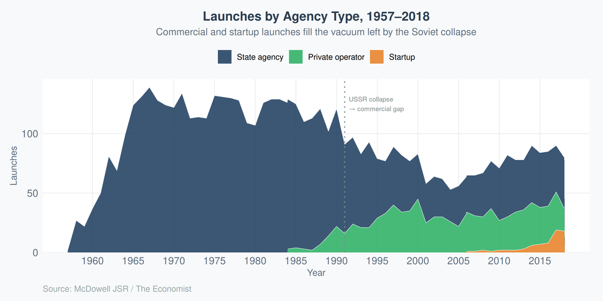

Annual launches split by agency type. State agencies dominate until the 1990s; private operators and startups grow steadily thereafter.

This graph covers total number of launches divided by different categories of the launches. There are state agencies which are mostly the departments of defense and other governmental scientific institutions. The second category are the private companies and the start-ups, the newest companies. The last two have an increasing tendency and are suposely taking over other agencies.

## 5.2 Era-Level Breakdown

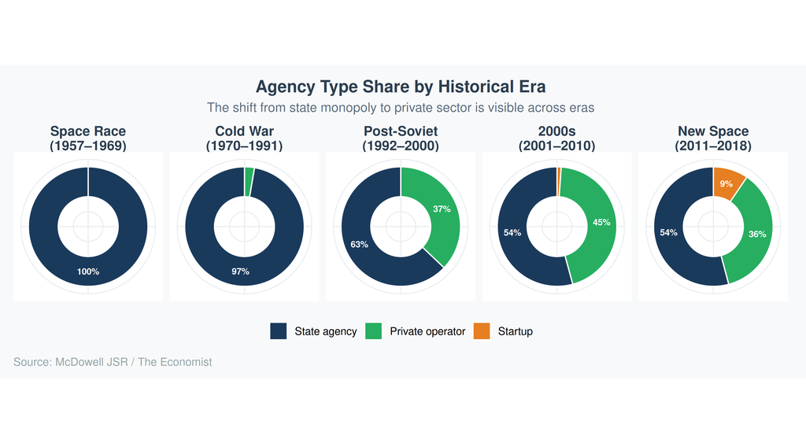

Share of launches by agency type within each historical era.

## 5.3 Top 15 Launch Agencies of All Time

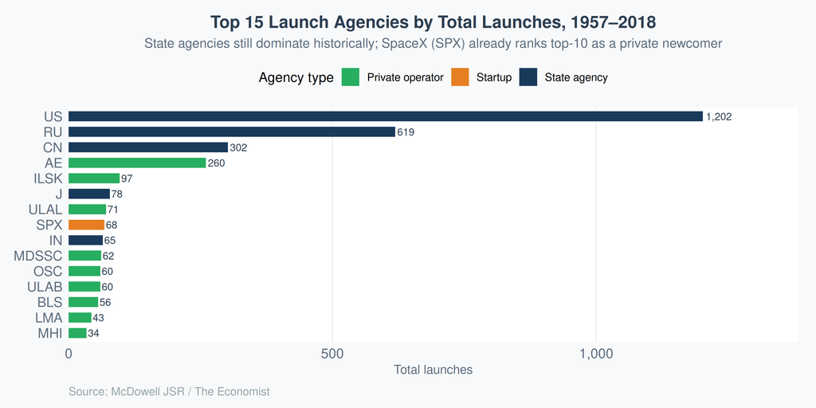

Top 15 agencies by total launches, coloured by agency type.

## 5.4 China’s Ascent

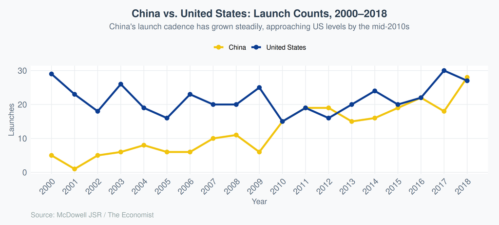

Chinese annual launches compared to United States launches, 2000–2018.